# Data Analysis Report 6

Will Kramlinger

Feb. 17, 2019

## Introduction

Exploratory data analysis (EDA) was conducted on a data set comprising 777 observations on 18 variables for US Colleges from the 1995 issue of US News and World Report. The number of applications (**apps**) sent to each college was considered as a response variable; it and potential predictors were examined in order to gauge the necessity of data cleansing before model fitting via various regression techniques. Analyses compared the efficacy of best subsets, coefficient shrinkage methods (ridge, lasso), and dimension reduction techniques (principal components regression (PCR), partial least squares (PLS)). Models were evaluated based on a criterion of test MSE minimization using a 50:50 train:test split; optimal tuning parameters for PCR and PLS were selected via 10-fold cross-validation.

## Data

The data set analyzed was the **College** data set included in the R package **ISLR**. The set includes observations for 777 colleges across 18 variables. For variable definitions, please refer to https://rdrr.io/cran/ISLR/man/College.html. The following shall presume the reader’s familarity with the variable names and their meanings, as they are used interchangeably. A check for missing data within the set revealed no problems.

## Analyses

#### Exploratory Data Analysis (EDA)

Initial EDA included examining the distributions for each variable, along with pairwise correlation between variables via visual inspection of correlation and scatterplot matrices. High correlations between variable pairs were seen for **enroll-accept** ($\rho$ = 0.9116), **enroll-f.Undergrad** ($\rho$ = 0.9646), **top25perc-top10perc** ($\rho$ = 0.8920), and **phd-terminal** ($\rho$ = 0.8496). The variable pair **top25perc-top10perc** posed obvious collinearity problems, as it was inferred that all of the **top10perc** for each college, was also represented within the **top25perc**. A new variable **top75to90** was thus calculated as

$top75to90 = top25perc - top10perc$

and then substituted in as a replacement for **top25perc**. The correlation between **top10perc-top75to90** subsequently decreased to $\rho$ = 0.0028.

An investigation of outliers and high leverage observations was also undertaken via residual diagnostic plots, which revealed that *Rutgers at New Brunswick* was an influential point; **this point was subsequently removed from analysis**, which brought the number of observations to *n* = 776.

A histogram of the response variable **Apps** was found to be heavily skewed to the right, which suggested a variable transformation may be needed; this is discussed below.

#### Variable Transformation and Selection

In response to these problems, possible transformations on the response were examined via Box-Cox transformation. Using the *boxCox()* function within the **car** package, the optimal $\lambda$ was found to be $0.\bar{50}$, which was simplified to $\lambda = 0.50$. The new response variable used for subsequent model fitting was thus $\sqrt{apps}$.

After the improvements were observed due to the response transformation, transformations on the predictor variables were not considered to maintain model interpretability.

#### Best Subsets, Ridge, Lasso

Using the transformed response and all 15 of the candidate predictor variables, best subsets regression was conducted using the *regsubsets()* function within the **leaps** package. **Based on a criterion of prediction error minimization, the optimal number of variables was found to be 11.** The test MSE for this method was found to be $MSE = 79.4125$.

Ridge and Lasso regression were conducted using the *glmnet()* function within the **glmnet** package. Tuning parameters were selected using 10-fold cross-validation via the *cv.glmnet()* function. The test MSE for ridge regression was found to be $MSE = 81.7738$. The test MSE for lasso regression was found to be $MSE = 80.8399$, with 13 variables; excluded variables included *terminal* and *outstate*.

#### Principal Components Regression (PCR)

Using the transformed response and all 15 of the candidate predictor variables, PCR was conducted using the *pcr()* function within the **pls** package according to the steps outlined in the textbook. By default, the function standardizes all predictor levels and conducts 10-fold cross-validation (CV) for each possible value of $M$ components. **Based on a criterion of prediction error minimization, the optimal number of components for PCR was found to be $M = 12$.** The test MSE for this method was found to be $MSE = 81.7806$.

#### Partial Least Squares (PLS)

PLS was conducted using the *plsr()* function within the **pls** package according to the steps outlined in the textbook. The function also performs the predictor standardization and CV steps, as mentioned for PCR. **Based on a criterion of prediction error minimization, the optimal number of components for PLS was found to be $M = 6$**. The test MSE found via PLS was found to be $MSE = 80.3527$, which was a bit lower than that found for PCR.

#### Discussion

While the minimum prediction errors between PCR and PLS did not greatly differ, of note is that PLS was ultimately able to achieve a smaller test MSE using a smaller number of components. This difference in performance is not wholly unexpected, as PLS utilizes information from the response variable in its identification of principal components, while PCR does not.

Contrary to previous weeks’ analyses, PCA methods performed comparably to the coefficient shrinkage methods. Just as poorer performance of PCA was previously attributed to information loss due to dimension reduction and inability to remove irrelevant data, comparable performance between these methods suggests that the pre-analysis variable selection and transformations were largely effective.

Of note in this model is the absence of the variable **terminal**, which was previously discussed as being strongly correlated with **phd**; the observation points to the ability of best subsets to weed out redundant information. The regression output for this model is found as Table 1.

The performance of the methods (each method’s test MSE) using different test:train splits is displayed as Fig. 1. The results show that, generally, the methods perform comparably with the exception of ridge regression, the plot of which deviates quite frequently from the other methods. This is likely attributable to the fact that ridge does not perform variable selection nor dimension reduction, and points to the advantages of the other methods, assuming proper data cleaning.

## Plots and Tables

```r
# ?College
str(df) # Private is binary, all others continuous numeric
cor(df[ , 2:18])
# pairs(df, cex = 0.5)
# High corr (say, > 0.8): Enroll-Accept, Enroll-F.Undergrad,
# Top10perc-Top25Perc, PhD-Terminal
summary(df) # Private has 565 / (565 + 212) = 72.71%
names(df) <- tolower(names(df)) # For ease of use

# for(i in 2:18) {
#   hist(df[ , i], xlab = colnames(df)[i])
# }
# rm(i)
# Normal: Grad Rate, S.F.Ratio (approx), Room.Board, Outstate, Top25perc
# Skewed right: Expend, perc.alumni, Personal, Books (very long tail/outliers?),
#               P.Undergrad, F.Undergrad, Top10perc, Enroll, Accept
# Skewed left: Terminal, PhD

full.model <- lm(apps ~ ., data = df)
summary(full.model) # SE(res) = 1041, Adj R-Sq = 92.76
vif(full.model) # accept, top10perc, top25perc > 5, enroll, f.undergrad > 10

summary(lm(apps ~ . - enroll - f.undergrad, data = df))
vif(lm(apps ~ . - enroll - f.undergrad, data = df))

# Modify terminal and top25perc
df$top75to90 <- df$top25perc - df$top10perc
# df$nonphdterm <- df$terminal - df$phd
df <- df[ , c(1:5, 7:19)]
# Re-run model with modified variables, and without enroll f.undergrad
full.model2 <- lm(apps ~ . - enroll - f.undergrad, data = df)
summary(full.model2) # SE(res) = 1062, Adj R-Sq = 92.47
vif(full.model2) # Pretty reasonable
# plot(full.model2)
2*sqrt((19 + 1)/(777 - 19 - 1)) # DFFITs threshold = 0.3251
which(dffits(full.model2) > 0.3251)
which(cooks.distance(full.model2) > 1) # Returns Rutgers at New Brunswick
# It seems very reasonable that Rutgers be taken out of the data
which(row.names(df) == "Rutgers at New Brunswick") # Row 484
df <- df[-484, ] # DELETE RUTGERS; New n = 776
# Re-run model with no Rutgers
full.model3 <- lm(apps ~ . - enroll - f.undergrad, data = df)
summary(full.model3) # SE(res) = 979.4, Adj R-Sq = 92.25; best error thus far
vif(full.model3) # About the same as VIF for 2
# plot(full.model3)
# Check out BoxCox
# box.full3 <- boxCox(full.model3)
# which(box.full3$y == max(box.full3$y)) # Returns 63
# box.full3$x[63] # Returns 0.5050.....  Use SQRT transform!
# Modify df$apps
full.model4 <- lm(sqrt(apps) ~ . - enroll - f.undergrad, data =df)
summary(full.model4) # SE(res) = 8.426, Adj R-Sq = 90.04
vif(full.model4) # Pretty reasonable
# plot(full.model4)
# Most worrisome is Purdue-West Lafayette, but not high leverage, low Cook's
# distance
# hist(sqrt(df$apps)) # Still a bit skewed right, but better
# hist(log(df$apps)) # Significantly better than sqrt(apps)
# Try log transform
full.model5 <- lm(log(apps) ~ . - enroll - f.undergrad, data =df)
summary(full.model5) # SE(res) = 0.5028, Adj R-Sq = 77.82
vif(full.model5) # Pretty reasonable
# plot(full.model5)

## Transform df to permanently exclude enroll and f.undergrad
df <- df[ , -c(4, 6)]
## Transform df to permanently have sqrt(apps) as response
df$sqrt.apps <- sqrt(df$apps)
df <- df[ , c(17, 1, 3:16)]

best.model <- lm(sqrt.apps ~ . - outstate - terminal - top75to90 - personal,
                 data = df)
summary(best.model)
vif(best.model)

save(df, file = "mod_df.rda")
```

```r
library(kableExtra)
load("tabler_lm.Rda")
table1 <- tabler.lm(best.model)
table1 %>%
  kable(align = "l") %>%
  kable_styling(bootstrap_options = c("striped", "hover", "condensed"),
                full_width = TRUE, font_size = 14, position = "center") %>%
  scroll_box(width = "100%", height = "250px")
```

|  | Coefficient | Std. Error | t-stat | P-value | VIF |
| --- | --- | --- | --- | --- | --- |
| (Intercept) | -0.0555 | 2.9416 | -0.0189 | 0.985 | NA |
| privateYes | -9.8881 | 1.0097 | -9.7932 | 0 | 2.209 |
| accept | 0.0085 | 2e-04 | 47.4565 | 0 | 1.832 |
| top10perc | 0.217 | 0.0265 | 8.1803 | 0 | 2.396 |
| p.undergrad | 7e-04 | 2e-04 | 2.8829 | 0.0041 | 1.481 |
| room.board | 0.0014 | 4e-04 | 4.0209 | 1e-04 | 1.657 |
| books | 0.0044 | 0.0019 | 2.3209 | 0.0206 | 1.056 |
| phd | 0.0271 | 0.0247 | 1.0935 | 0.2745 | 1.783 |
| s.f.ratio | 0.5145 | 0.1043 | 4.9314 | 0 | 1.862 |
| perc.alumni | -0.0765 | 0.0319 | -2.3983 | 0.0167 | 1.712 |
| expend | 7e-04 | 1e-04 | 7.3123 | 0 | 2.611 |
| grad.rate | 0.1281 | 0.0234 | 5.4789 | 0 | 1.765 |
| ———- | ———- | ———- | ———- | ———- | ———- |
| s | 8.4205 |  |  |  |  |
| Residual DF | 764 |  |  |  |  |
| R Squared | 0.9019 |  |  |  |  |
| Adj. R Squared | 0.9005 |  |  |  |  |
| F, numDF, denomDF | 639 | 11 | 764 |  |  |

Table 1: Regression output for 11-predictor model selected via best subsets. This model provided the lowest test MSE of all methods, holding the train:test data split constant.

```r
load(file = "mod_df.rda")
library(leaps)
library(glmnet)
library(pls)

mse.table <- matrix(nrow = 50, ncol = 6)
colnames(mse.table) <- c("Least Squares", "Best Subsets", "Ridge", "Lasso",
                         "PCR", "PLS")

for (i in 1:50) {
  # Split the data set into a training set and a test set
  set.seed(i) # Originally equal to 1
  train=sample(1:nrow(df), nrow(df)/2)
  test=(-train)

  y <- df$sqrt.apps
  x <- model.matrix(sqrt.apps ~ ., data = df)[, -1]

  # Fit model using least-squares
  ols.model <- lm(sqrt.apps ~ ., data = df[train, ])
  ols.beta <- matrix(ols.model$coefficients)
  # Calculate test responses
  pred <- model.matrix(sqrt.apps ~ ., data = df)[test,] %*% ols.beta
  mse.ols <- mean((df$sqrt.apps[test] - pred)^2) # OLS MSE = 74.27048

  # Use best subsets
  regfit.best=regsubsets(sqrt.apps ~ . ,data=df[train, ], nvmax = 15)
  best.test.mat=model.matrix(sqrt.apps ~ .,data=df[test,])
  best.val.errors=rep(NA,15)

  for(j in 1:15){
    coefi=coef(regfit.best,id=j)
    pred=best.test.mat[,names(coefi)]%*%coefi
    best.val.errors[j]=mean(((df$sqrt.apps[test] - pred)^2))
  }
  best.val.errors

  mse.subsets <- best.val.errors[which(best.val.errors == min(best.val.errors))]
  # Best subsets MSE = OLS MSE = 74.27048

  # Use ridge regression
  grid=10^seq(10,-2,length=100)
  ridge.mod=glmnet(x[train, ],y[train],alpha=0,lambda=grid, thresh=1e-12)
  # Get optimal lambda
  ridge.cv.out=cv.glmnet(x[train, ],y[train],alpha=0)

  ridge.bestlam=ridge.cv.out$lambda.min
  ridge.bestlam # Returns best lambda = 2.766425
  # Get predictions and MSE
  ridge.pred=predict(ridge.mod,s=ridge.bestlam,newx=x[test, ])
  mse.ridge <- mean((ridge.pred-y[test])^2) # Returns Ridge MSE = 83.24518

  # Use lasso regression
  lasso.mod=glmnet(x[train, ],y[train],alpha=1,lambda=grid)

  set.seed(1)
  # Get optimal lambda
  lasso.cv.out=cv.glmnet(x[train, ],y[train],alpha=1)

  lasso.bestlam=lasso.cv.out$lambda.min # Returns best lambda = 0.05960082
  lasso.pred=predict(lasso.mod,s=lasso.bestlam,newx=x[test, ])
  mse.lasso <- mean((lasso.pred-y[test])^2)
  # Returns Lasso MSE = 74.43312; lower than Ridge, almost as good as OLS
  lasso.out=glmnet(x,y,alpha=1,lambda=grid)
  lasso.coef=predict(lasso.out,type="coefficients",s=lasso.bestlam)[1:15,]
  lasso.coef # Non-zero: ALL VARIABLES!
  lasso.coef[lasso.coef!=0]

  # Use PCR
  pcr.fit=pcr(sqrt.apps~., data=df,scale=TRUE,validation="CV")
  # PCR standardizes the predictors with scale = TRUE, CV is 10-fold CV
  # The resulting fit can be examined using summary()
  summary(pcr.fit) # PCR M = 12 components for entire data set
  # The CV scores are sqrt(MSE)!!!  To get MSE, we must square.
  # We then perform PCR on the training data and evaluate its test performance.
  set.seed(1)
  pcr.fit=pcr(sqrt.apps ~., data=df,subset=train,scale=TRUE, validation="CV")
  summary(pcr.fit) # PCR M = 14 components for test set fit
  # We can also plot cross-validation scores using the validationplot() function.
  # val.type = "MSEP" gives the cross-validation MSE plot
  # validationplot(pcr.fit,val.type="MSEP")
  pcr.pred=predict(pcr.fit,x[test,],
                   ncomp=which(pcr.fit$validation$PRESS ==
                                 min(pcr.fit$validation$PRESS)))
  mse.pcr <- mean((pcr.pred-y[test])^2)
  # Returns PCR MSE = 74.292576; almost as good as least squares

  # We implement PLS using plsr()
  set.seed(1)
  pls.fit=plsr(sqrt.apps~., data=df,subset=train,scale=TRUE, validation="CV")
  summary(pls.fit)
  # validationplot(pls.fit,val.type="MSEP")
  pls.pred=predict(pls.fit,x[test,],ncomp=which(pls.fit$validation$PRESS ==
                                                  min(pls.fit$validation$PRESS)))
  mse.pls <- mean((pls.pred-y[test])^2)
  # Returns PLS MSE = 74.61448

  mse.table[i, 1] <- mse.ols
  mse.table[i, 2] <- mse.subsets
  mse.table[i, 3] <- mse.ridge
  mse.table[i, 4] <- mse.lasso
  mse.table[i, 5] <- mse.pcr
  mse.table[i, 6] <- mse.pls
}

save(mse.table, file = "mse_table.rda")
plotdf <- data.frame(mse.table)
```

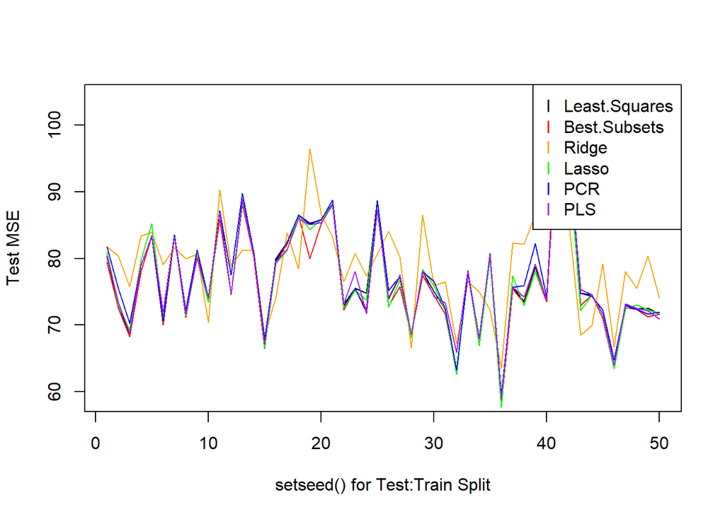

```r
plot(plotdf$Least.Squares ~ seq(1:50), type = "l", col = "black",
     xlab = "setseed() for Test:Train Split", ylab = "Test MSE")
lines(plotdf$Best.Subsets, col = "red")
lines(plotdf$Ridge, col = "orange")
lines(plotdf$Lasso, col = "green")
lines(plotdf$PCR, col = "blue")
lines(plotdf$PLS, col = "purple")
legend("topright",
       legend = colnames(plotdf),
       col = c("black", "red", "orange", "green", "blue", "purple"),
       pch = "l",
       horiz = FALSE)
```

Fig. 1: Test MSE vs. *x*, where x is the input parameter of setseed() used for splitting the data set into training and test sets. The performance of all methods remains similar except for ridge regression, which does not perform variable selection or dimension reduction.

## Appendix I: R Code

The following code supplements that found above and has not been edited for cleanliness.

```r
#### Move forward with full.model4 (sqrt(y), no enroll, no f.undergrad)
library(leaps)
# Split the data set into a training set and a test set
set.seed(1) # Originally equal to 1
train=sample(1:nrow(df), nrow(df)/2)
test=(-train)

y <- df$sqrt.apps
x <- model.matrix(sqrt.apps ~ ., data = df)[, -1]

# Fit model using least-squares
ols.model <- lm(sqrt.apps ~ ., data = df[train, ])
ols.beta <- matrix(ols.model$coefficients)
# Calculate test responses
pred <- model.matrix(sqrt.apps ~ ., data = df)[test,] %*% ols.beta
mse.ols <- mean((df$sqrt.apps[test] - pred)^2) # OLS MSE = 80.21417

# Use best subsets
regfit.best=regsubsets(sqrt.apps ~ . ,data=df[train, ], nvmax = 15)
best.test.mat=model.matrix(sqrt.apps ~ .,data=df[test,])
best.val.errors=rep(NA,15)

for(j in 1:15){
  coefi=coef(regfit.best,id=j)
  pred=best.test.mat[,names(coefi)]%*%coefi
  best.val.errors[j]=mean(((df$sqrt.apps[test] - pred)^2))
}
best.val.errors
```

```
##  [1] 144.18998 107.34733  98.11111  91.07442  88.13670  84.58297  81.31922
##  [8]  80.22951  79.62542  80.11982  79.41252  80.04827  80.14640  80.17351
## [15]  80.21417
```

```r
mse.subsets <- best.val.errors[which(best.val.errors == min(best.val.errors))]
# Best subsets MSE = 79.41252

# Use ridge regression
grid=10^seq(10,-2,length=100)
ridge.mod=glmnet(x[train, ],y[train],alpha=0,lambda=grid, thresh=1e-12)
# Get optimal lambda
ridge.cv.out=cv.glmnet(x[train, ],y[train],alpha=0)

ridge.bestlam=ridge.cv.out$lambda.min
ridge.bestlam # Returns best lambda = 2.64715
```

```
## [1] 2.647147
```

```r
# Get predictions and MSE
ridge.pred=predict(ridge.mod,s=ridge.bestlam,newx=x[test, ])
mse.ridge <- mean((ridge.pred-y[test])^2) # Returns Ridge MSE = 81.77377

# Use lasso regression
lasso.mod=glmnet(x[train, ],y[train],alpha=1,lambda=grid)

set.seed(1)
# Get optimal lambda
lasso.cv.out=cv.glmnet(x[train, ],y[train],alpha=1)

lasso.bestlam=lasso.cv.out$lambda.min # Returns best lambda = 0.15869
lasso.pred=predict(lasso.mod,s=lasso.bestlam,newx=x[test, ])
mse.lasso <- mean((lasso.pred-y[test])^2)
# Returns Lasso MSE = 80.83988; lower than Ridge, slightly better than OLS
lasso.out=glmnet(x,y,alpha=1,lambda=grid)
lasso.coef=predict(lasso.out,type="coefficients",s=lasso.bestlam)[1:15,]
lasso.coef
```

```
##   (Intercept)    privateYes        accept     top10perc   p.undergrad
##  1.5918516138 -9.5026528123  0.0085379720  0.2099900707  0.0005677203
##      outstate    room.board         books      personal           phd
##  0.0000000000  0.0013852237  0.0033465050  0.0006101362  0.0281776907
##      terminal     s.f.ratio   perc.alumni        expend     grad.rate
##  0.0000000000  0.4425720061 -0.0474943801  0.0006242039  0.1147064776
```

```r
lasso.coef[lasso.coef!=0] # Non-zero: terminal, outstate
```

```
##   (Intercept)    privateYes        accept     top10perc   p.undergrad
##  1.5918516138 -9.5026528123  0.0085379720  0.2099900707  0.0005677203
##    room.board         books      personal           phd     s.f.ratio
##  0.0013852237  0.0033465050  0.0006101362  0.0281776907  0.4425720061
##   perc.alumni        expend     grad.rate
## -0.0474943801  0.0006242039  0.1147064776
```

```r
# Use PCR
# The CV scores are sqrt(MSE)!!!  To get MSE, we must square.
# We then perform PCR on the training data and evaluate its test performance.
set.seed(1)
pcr.fit=pcr(sqrt.apps ~., data=df,subset=train,scale=TRUE, validation="CV")
summary(pcr.fit) # PCR M = 12 components for train set fit
```

```
## Data:    X dimension: 388 15
##  Y dimension: 388 1
## Fit method: svdpc
## Number of components considered: 15
##
## VALIDATION: RMSEP
## Cross-validated using 10 random segments.
##        (Intercept)  1 comps  2 comps  3 comps  4 comps  5 comps  6 comps
## CV           26.19    25.88    14.61    14.68    14.66     14.5    14.32
## adjCV        26.19    25.88    14.60    14.67    14.65     14.5    14.36
##        7 comps  8 comps  9 comps  10 comps  11 comps  12 comps  13 comps
## CV       10.16    9.919    9.653     9.394     9.427     8.315     8.376
## adjCV    10.09    9.855    9.619     9.370     9.408     8.280     8.350
##        14 comps  15 comps
## CV        8.348     8.357
## adjCV     8.321     8.330
##
## TRAINING: % variance explained
##            1 comps  2 comps  3 comps  4 comps  5 comps  6 comps  7 comps
## X           31.249    50.01    58.18    65.34    71.05    76.59    81.49
## sqrt.apps    2.197    69.04    69.18    69.25    71.56    71.70    85.81
##            8 comps  9 comps  10 comps  11 comps  12 comps  13 comps
## X            85.29    88.71     91.49     93.93     96.05     97.74
## sqrt.apps    86.87    87.31     88.19     88.21     90.76     90.81
##            14 comps  15 comps
## X             98.94    100.00
## sqrt.apps     90.94     90.95
```

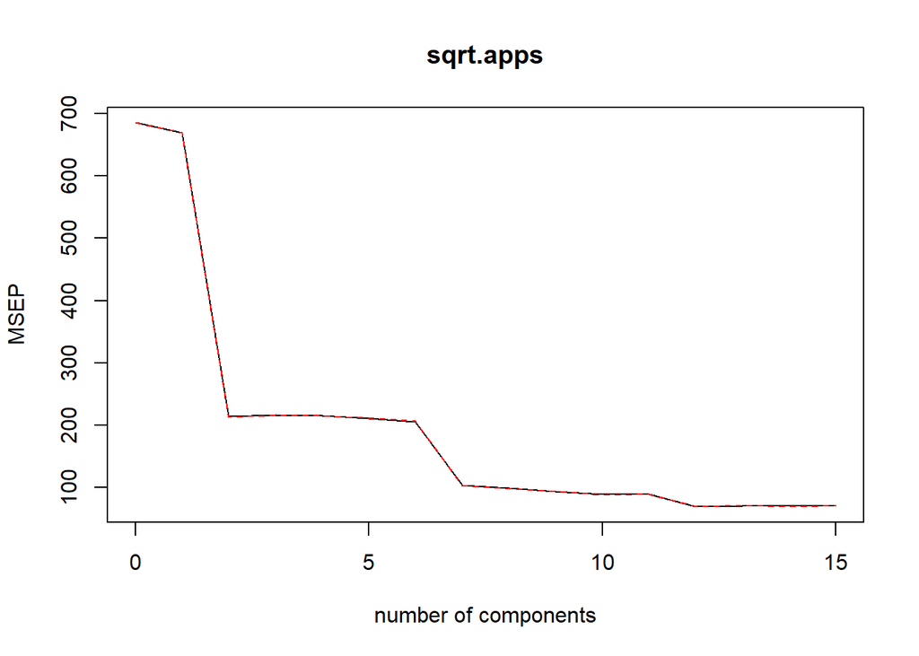

```r
# We can also plot cross-validation scores using the validationplot() function.
# val.type = "MSEP" gives the cross-validation MSE plot
validationplot(pcr.fit,val.type="MSEP")
```

```r
pcr.pred=predict(pcr.fit,x[test,],
                 ncomp=which(pcr.fit$validation$PRESS ==
                               min(pcr.fit$validation$PRESS)))
mse.pcr <- mean((pcr.pred-y[test])^2)
# Returns PCR MSE = 81.78060; almost as good as least squares

# We implement PLS using plsr()
set.seed(1)
pls.fit=plsr(sqrt.apps~., data=df,subset=train,scale=TRUE, validation="CV")
summary(pls.fit) # PLS M = 6 comps
```

```
## Data:    X dimension: 388 15
##  Y dimension: 388 1
## Fit method: kernelpls
## Number of components considered: 15
##
## VALIDATION: RMSEP
## Cross-validated using 10 random segments.
##        (Intercept)  1 comps  2 comps  3 comps  4 comps  5 comps  6 comps
## CV           26.19    12.63    10.84    8.591    8.373    8.361    8.349
## adjCV        26.19    12.62    10.83    8.560    8.343    8.335    8.323
##        7 comps  8 comps  9 comps  10 comps  11 comps  12 comps  13 comps
## CV       8.351    8.357    8.357     8.357     8.357     8.357     8.357
## adjCV    8.325    8.330    8.330     8.330     8.330     8.330     8.330
##        14 comps  15 comps
## CV        8.357     8.357
## adjCV     8.330     8.330
##
## TRAINING: % variance explained
##            1 comps  2 comps  3 comps  4 comps  5 comps  6 comps  7 comps
## X            19.53    43.88    54.80    58.70    64.74    69.66    73.65
## sqrt.apps    77.25    83.69    90.16    90.83    90.93    90.94    90.95
##            8 comps  9 comps  10 comps  11 comps  12 comps  13 comps
## X            77.65    82.58     85.75     88.47     92.36     95.89
## sqrt.apps    90.95    90.95     90.95     90.95     90.95     90.95
##            14 comps  15 comps
## X             97.58    100.00
## sqrt.apps     90.95     90.95
```

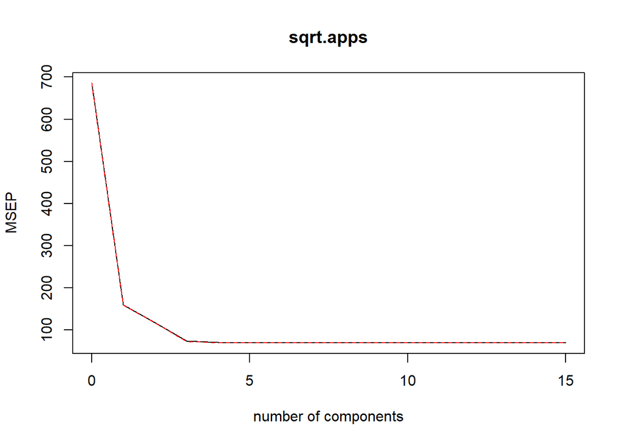

```r
validationplot(pls.fit,val.type="MSEP")
```

```r
pls.pred=predict(pls.fit,x[test,],ncomp=which(pls.fit$validation$PRESS ==
                                                min(pls.fit$validation$PRESS)))
mse.pls <- mean((pls.pred-y[test])^2)
# Returns PLS MSE = 80.35265
```